# Projet d’apprentissage statistique

Adrien Riaux

18/01/2022

# Motivation et positionnement du projet

Nous avons choisi le sujet concernant la rétinopathie diabétique. Maladie résultant de la complication d’un diabète et de l’atteinte des vaisseaux de la rétine, mettant en jeu un pronostic visuel. C’est une maladie compliquée à traiter et qui a de graves conséquences. C’est pourquoi l’analyse de ce dataset, ainsi que la création d’un modèle prédictif sont très intéressants pour nous.

De plus le *diabetic retinopathy debrecen dataset* nous fournit un nombre conséquent d’individus et des varibles pour mener à bien cette analyse (ce qui devrait nous éviter d’être en underfitting ou overfitting). Il semblerait qu’il n’y ait pas de valeurs manquantes dans le dataset (même si nous allons le vérifier par la suite).

La tâche à réaliser pour cette analyse est une classification, puisqu’il faut séparer les cas des patients sains de ceux malades.

L’ensemble des données contient des caractéristiques extraites des images *Messidor* dans le but de prédire si une personne est atteinte de rétinopathie diabétique. Toutes les caractéristiques représentent soit une lésion détectée, soit une caratéristique descriptive d’une partie anatomique, ou un descripteur au niveau de l’image.

# Analyse descriptive

Les informations qui nous sont fournis sur le dataset sont les suivantes :

V1) Le résultat binaire de l’évaluation de la qualité. 0 = mauvaise qualité 1 = qualité suffisante.

V2) Le résultat binaire du pré-dépistage, où 1 indique une anomalie rétinienne sévère et 0 son absence.

V3-V8) Les résultats de la détection MA. Chaque valeur de caractéristique représente le nombre d’AM trouvées aux niveaux de confiance alpha = 0,5, . . . , 1, respectivement.

V9-V16) Contiennent les mêmes informations que les variables 3-8, mais pour les exsudats. Comme les exsudats sont représentés par un ensemble de points plutôt que le nombre de pixels construisant les lésions, ces caractéristiques sont normalisées en divisant le nombre de lésions avec le diamètre de la ROI pour compenser des images de différentes tailles.

V17) La distance euclidienne du centre de la macula et le centre du disque optique pour fournir des informations importantes concernant l’état du patient. Cette fonctionnalité est également normalisé avec le diamètre de la ROI.

V18) Le diamètre du disque optique.

V19) Le résultat binaire de la classification AM/FM.

V20) Étiquette de classe. 1 = contient des signes de DR (label cumulatif pour les classes Messidor 1, 2, 3), 0 = aucun signe de DR.

Dans un premier temps, nous allons procéder à une analyse descriptive des données. En particulier, la distribution des différentes variables, et des liens ou des dépendances entres celles-ci.

Pour cela il nous faut commencer par charger nos données dans un dataframe. Ce qui facilite énormément les manipulation.

```r
#On récupère nos données depuis le fichier texte
data = read.table("messidor_features.txt", header = FALSE, sep = ",")
head(data)
```

|  | V1 | V2 | V3 | V4 | V5 | V6 | V7 | V8 | V9 | V10 | V11 | V12 | V13 | V14 | V15 | V16 | V17 | V18 | V19 | V20 |
| --- | --- | --- | --- | --- | --- | --- | --- | --- | --- | --- | --- | --- | --- | --- | --- | --- | --- | --- | --- | --- |
| 1 | 1 | 1 | 22 | 22 | 22 | 19 | 18 | 14 | 49.89576 | 17.775994 | 5.270920 | 0.771761 | 0.018632 | 0.006864 | 0.003923 | 0.003923 | 0.486903 | 0.100025 | 1 | 0 |
| 2 | 1 | 1 | 24 | 24 | 22 | 18 | 16 | 13 | 57.70994 | 23.799994 | 3.325423 | 0.234185 | 0.003903 | 0.003903 | 0.003903 | 0.003903 | 0.520908 | 0.144414 | 0 | 0 |
| 3 | 1 | 1 | 62 | 60 | 59 | 54 | 47 | 33 | 55.83144 | 27.993933 | 12.687485 | 4.852282 | 1.393889 | 0.373252 | 0.041817 | 0.007744 | 0.530904 | 0.128548 | 0 | 1 |
| 4 | 1 | 1 | 55 | 53 | 53 | 50 | 43 | 31 | 40.46723 | 18.445954 | 9.118901 | 3.079428 | 0.840261 | 0.272434 | 0.007653 | 0.001531 | 0.483284 | 0.114790 | 0 | 0 |
| 5 | 1 | 1 | 44 | 44 | 44 | 41 | 39 | 27 | 18.02625 | 8.570709 | 0.410381 | 0.000000 | 0.000000 | 0.000000 | 0.000000 | 0.000000 | 0.475935 | 0.123572 | 0 | 1 |
| 6 | 1 | 1 | 44 | 43 | 41 | 41 | 37 | 29 | 28.35640 | 6.935636 | 2.305771 | 0.323724 | 0.000000 | 0.000000 | 0.000000 | 0.000000 | 0.502831 | 0.126741 | 0 | 1 |

Ce tableau nous permet d’observer notre dataset de manière globale dans un premier temps. Il nous donne un aperçu des valeurs prisent par chaque variables, ainsi que leur type (int, num…). Les variables 1, 2, 19 et 20 sont des variables de type catégorielles prenant des valeurs entre {0,1}. Pour en être sûr nous allons vérifier les valeurs uniques de ces variables.

```r
vec <- c(1,2,19,20) #Numéro des colonnes qui semble être catégorielles
for (i in vec) {
  print(unique(data[,i]))
}
```

```
[1] 1 0
[1] 1 0
[1] 1 0
[1] 0 1
```

Ce résultat nous confirme que nous avons bien 4 variables de type catégorielles. De plus, à l’aide des informations qui nous sont fournis sur le site du dataset, nous savons que la dernière variable est celle du résultat de l’analyse. Elle nous indique si un patient est malade ou sain.

Désormais nous allons convertir le type de ces 4 variables en un type catégorielle (à savoir en factor pour le langage R).

```r
for (i in vec){
  data[,i] <- as.factor(data[,i])
}

sapply(data, class)
```

```
       V1        V2        V3        V4        V5        V6        V7
 "factor"  "factor" "integer" "integer" "integer" "integer" "integer"
       V8        V9       V10       V11       V12       V13       V14
"integer" "numeric" "numeric" "numeric" "numeric" "numeric" "numeric"
      V15       V16       V17       V18       V19       V20
"numeric" "numeric" "numeric" "numeric"  "factor"  "factor"
```

Maintenant que nous avons le bon type pour chacune de nos variables, nous pouvons vérifer si nous avons des valeurs nulles. La commande str() nous donne de nouveau des informations sur les valeurs et le type de chaque variables. Sachant que dans la description du dataset, il y a indiqué 1151 observations et aucune valeur manquante.

```r
#On vérifie le type de chaque variables et si il y des valeurs nulles
str(data)
```

```
'data.frame':   1151 obs. of  20 variables:
 $ V1 : Factor w/ 2 levels "0","1": 2 2 2 2 2 2 2 2 2 2 ...
 $ V2 : Factor w/ 2 levels "0","1": 2 2 2 2 2 2 1 2 2 2 ...
 $ V3 : int  22 24 62 55 44 44 29 6 22 79 ...
 $ V4 : int  22 24 60 53 44 43 29 6 21 75 ...
 $ V5 : int  22 22 59 53 44 41 29 6 18 73 ...
 $ V6 : int  19 18 54 50 41 41 27 6 15 71 ...
 $ V7 : int  18 16 47 43 39 37 25 2 13 64 ...
 $ V8 : int  14 13 33 31 27 29 16 1 10 47 ...
 $ V9 : num  49.9 57.7 55.8 40.5 18 ...
 $ V10: num  17.78 23.8 27.99 18.45 8.57 ...
 $ V11: num  5.27 3.33 12.69 9.12 0.41 ...
 $ V12: num  0.772 0.234 4.852 3.079 0 ...
 $ V13: num  0.0186 0.0039 1.3939 0.8403 0 ...
 $ V14: num  0.00686 0.0039 0.37325 0.27243 0 ...
 $ V15: num  0.00392 0.0039 0.04182 0.00765 0 ...
 $ V16: num  0.00392 0.0039 0.00774 0.00153 0 ...
 $ V17: num  0.487 0.521 0.531 0.483 0.476 ...
 $ V18: num  0.1 0.144 0.129 0.115 0.124 ...
 $ V19: Factor w/ 2 levels "0","1": 2 1 1 1 1 1 1 2 1 1 ...
 $ V20: Factor w/ 2 levels "0","1": 1 1 2 1 2 2 2 1 2 2 ...
```

Il n’y a pas de valeurs nulle dans notre dataset. De plus chaque variables possède désormais le bon type. Nous allons pouvoir procéder à l’analyse préliminaire de nos données.

```r
#On applique sur chaque colonne des statistiques de bases (min, max, moyenne, quartile, etc.)
summary(data)
```

```
 V1       V2             V3               V4               V5
 0:   4   0:  94   Min.   :  1.00   Min.   :  1.00   Min.   :  1.00
 1:1147   1:1057   1st Qu.: 16.00   1st Qu.: 16.00   1st Qu.: 15.00
                   Median : 35.00   Median : 35.00   Median : 32.00
                   Mean   : 38.43   Mean   : 36.91   Mean   : 35.14
                   3rd Qu.: 55.00   3rd Qu.: 53.00   3rd Qu.: 51.00
                   Max.   :151.00   Max.   :132.00   Max.   :120.00
       V6              V7              V8              V9
 Min.   :  1.0   Min.   : 1.00   Min.   : 1.00   Min.   :  0.3493
 1st Qu.: 14.0   1st Qu.:11.00   1st Qu.: 8.00   1st Qu.: 22.2716
 Median : 29.0   Median :25.00   Median :18.00   Median : 44.2491
 Mean   : 32.3   Mean   :28.75   Mean   :21.15   Mean   : 64.0967
 3rd Qu.: 48.0   3rd Qu.:43.00   3rd Qu.:32.00   3rd Qu.: 87.8041
 Max.   :105.0   Max.   :97.00   Max.   :89.00   Max.   :403.9391
      V10               V11               V12
 Min.   :  0.000   Min.   :  0.000   Min.   : 0.00000
 1st Qu.:  7.939   1st Qu.:  1.249   1st Qu.: 0.08155
 Median : 17.038   Median :  4.423   Median : 0.48483
 Mean   : 23.088   Mean   :  8.705   Mean   : 1.83649
 3rd Qu.: 31.306   3rd Qu.: 11.767   3rd Qu.: 1.92165
 Max.   :167.131   Max.   :106.070   Max.   :59.76612
      V13                V14                 V15
 Min.   : 0.00000   Min.   : 0.000000   Min.   :0.000000
 1st Qu.: 0.00000   1st Qu.: 0.000000   1st Qu.:0.000000
 Median : 0.02225   Median : 0.001554   Median :0.000000
 Mean   : 0.56074   Mean   : 0.212290   Mean   :0.085674
 3rd Qu.: 0.19195   3rd Qu.: 0.038450   3rd Qu.:0.004832
 Max.   :51.42321   Max.   :20.098605   Max.   :5.937799
      V16                V17              V18          V19     V20
 Min.   :0.000000   Min.   :0.3678   Min.   :0.05791   0:764   0:540
 1st Qu.:0.000000   1st Qu.:0.5029   1st Qu.:0.09580   1:387   1:611
 Median :0.000000   Median :0.5233   Median :0.10662
 Mean   :0.037225   Mean   :0.5232   Mean   :0.10843
 3rd Qu.:0.003851   3rd Qu.:0.5437   3rd Qu.:0.11959
 Max.   :3.086753   Max.   :0.5922   Max.   :0.21920
```

La commande summary nous donne des informations statistiques de base par variables (sauf pour les variables catégorielles, ce qui n’aurait pas de sens).

Pour les variables 1 et 2, on peut remarquer que le nombre de 0 est très faible. Ce qui met en valeur le faible nombre d’évaluation de mauvaise qualité. Cela nous indique aussi que la majorité des patients ont eu un résultat positif au pré-dépistage. Alors que pour la variable 20, on peut voir que l’on à peu près le même nombre de patients malades que sains. On peut donc en conclure sur la faible efficacité du pré-dépistage.

On peut observer le nombre en % de cas malades/sains, afin d’avoir une meilleur visibilité sur la variable 20.

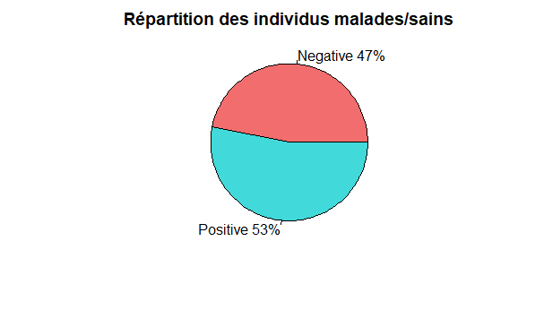

```r
#On visualise le nombre de cas positif et négatif de notre dataset
my_count <- table(data$V20)
pct <- round(my_count/sum(my_count)*100)
lbls <- c("Negative", "Positive")
lbls <- paste(lbls,pct)
lbls <- paste(lbls,"%", sep = "")

pie(my_count, labels = lbls, main = "Répartition des individus malades/sains", col = c("#F26D6D","#41D9D9"))
```

Ici en rouge, les patients negatifs au RD, et en bleu les patients positifs au RD. Ce qui veut dire que les classes sont équilibrées. Cela nous facilitera la tâche lors de la classification supervisé, car nous n’auront pas à jouer sur les poids des classes pour rééquilibrer des classes disproportionnées.

Sachant que la variable 20 constitue notre “target”, nous allons analyser la répartition des autres variables en fonction de celle-ci. Pour cela nous utilisons des boxplots. En séparant les cas sains des cas malades.(Il suffit de cliquer sur un des graphiques pour l’afficher en version grande plus bas).

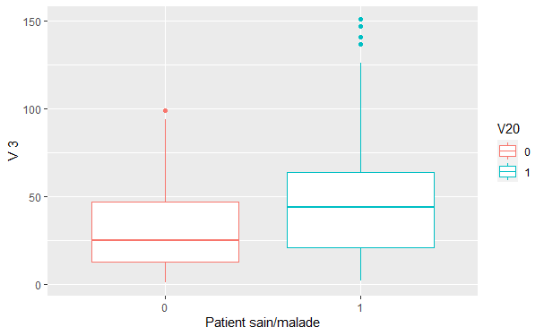

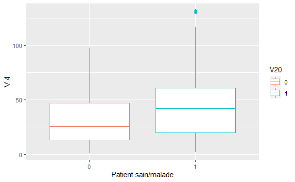

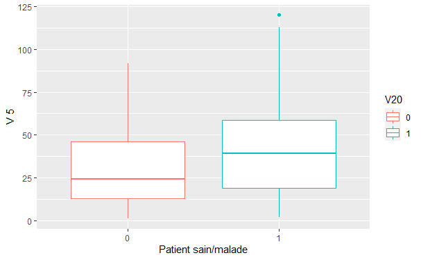

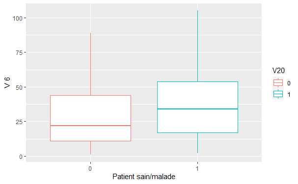

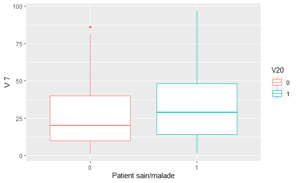

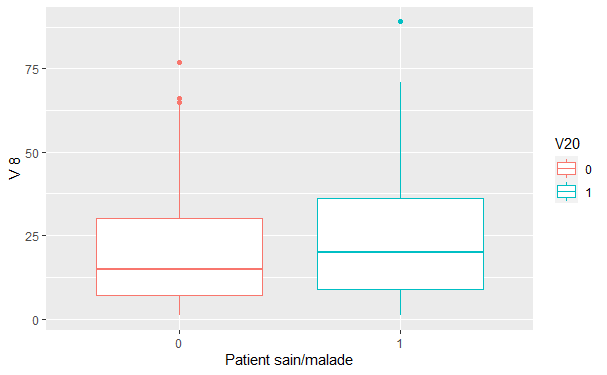

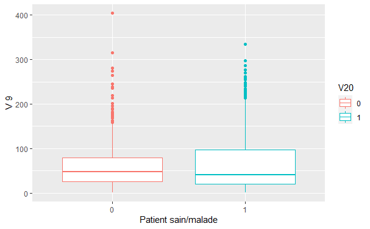

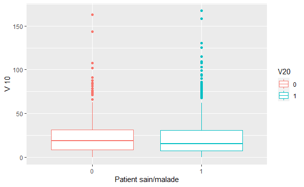

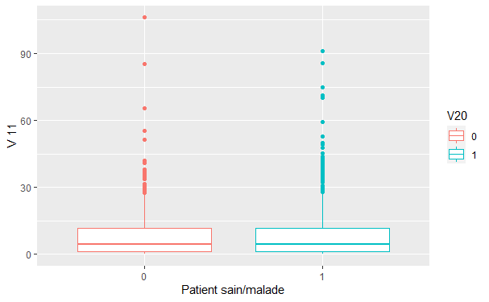

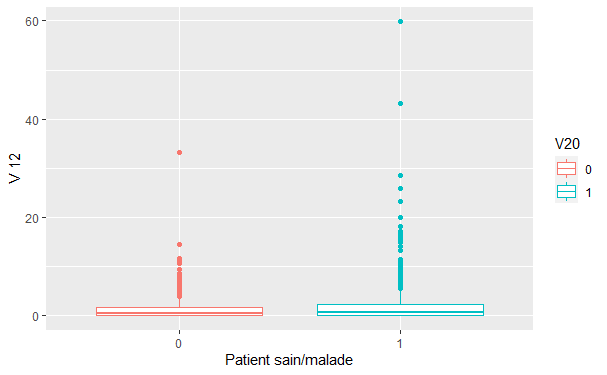

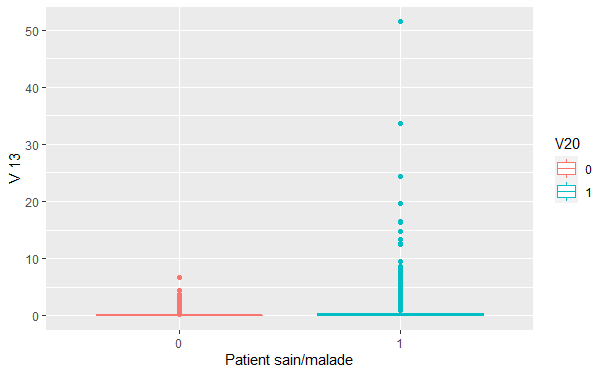

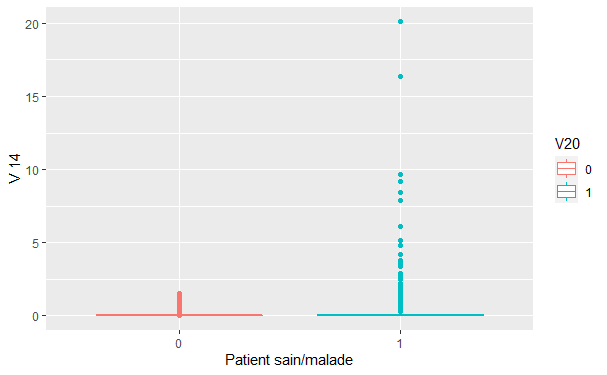

[3 more figures not shown]

```r
library(ggplot2)
#A l'aide de boxplot on regarde la distribution des individus pour chaque variables
for (i in 3:17){
  g <- ggplot(data, aes(x = V20, y = data[,i]))
  print(g + geom_boxplot(aes(color = V20))
  + xlab("Patient sain/malade")
  + ylab(paste("V",i)))

}
```

Ces boxplots sont très intéressants à analyser. Car ils nous donnent des informations sur la répartitions des valeurs par variable, et en fonction de la variable “target”. On peut voir pour les variables 3 à 8 une légère différence de la répartition des valeurs entre un patient sain et un malade. Il semblerait que les patients malades aient des résultats plus élevés à la détection MA.

On remarque aussi que pour certaines variables (12 à 16), les patients malades semblent plus souvent répertoriés comme des “outliers” (valeurs abérantes).

Nous allons donc maintenant nous intéresser d’un peu plus près au variable 3 à 8.

[output not shown]

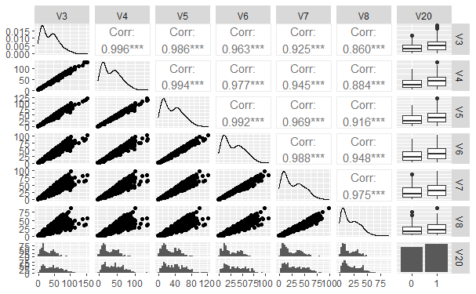

```r
#Analyse des variables 3 à 8
library(GGally)
GGally::ggpairs(data[c(3:8,20)])
```

Ce graphique met en valeur deux points très importants pour les variables 3 à 8 :

Tout d’abord, elles ont toutes la même distribution. Ce qui semble logique puisqu’elles sont toutes liées à un test commun.

Ensuite, ces variables ont de très forte corrélation (positive). Ce qui veut dire qu’il y a de fortes dépendances entre ces variables.

On peut donc s’intéresser aux corrélations entre toutes les variables de notre dataset. Pour calculer une matrice de corrélation il nous faut uniquement des valeurs numérique. On peut donc enlever les variables catégorielles de notre dataset. Sachant qu’il serait très peu pertinent de les inclure dans l’analyse, puisqu’elles constituent les résultats d’analyses postérieurs à celles des variables 3 à 18.

On commence par définir un dataframe ne contenant que les informations que l’on veut traiter.

```r
#Pour avoir la matrice de corrélation entre nos variables, il faut qu'elles soient de type numérique
corr_data <- cor(data[3:18])
ncol(corr_data)
```

```
[1] 16
```

On a bien que les 16 colonnes de notre dataset, qui sont de type “numeric”.

On peut donc construire notre matrice de corrélation. Pour cela on construit d’abord un tableau contenant la corrélation entre chaque combinaisons de variables possibles.

```r
#Préparation des données pour avoir la corrélation entre variables
library(reshape2)
library(scales)
melt_data <- reshape2::melt(corr_data, varnames = c("x","y"), value.name = "Correlation" )
melt_data <- melt_data[order(melt_data$Correlation),]
melt_data
```

|  | x | y | Correlation |
| --- | --- | --- | --- |
| 87 | V9 | V8 | -3.755061e-01 |
| 102 | V8 | V9 | -3.755061e-01 |
| 71 | V9 | V7 | -3.498107e-01 |
| 101 | V7 | V9 | -3.498107e-01 |
| 55 | V9 | V6 | -3.099497e-01 |
| 100 | V6 | V9 | -3.099497e-01 |
| 39 | V9 | V5 | -2.831879e-01 |
| 99 | V5 | V9 | -2.831879e-01 |
| 23 | V9 | V4 | -2.447041e-01 |
| 98 | V4 | V9 | -2.447041e-01 |

[output cut: 246 more lines]

Ensuite on peut afficher à l’aide d’une heatmap, notre matrice de corrélation.

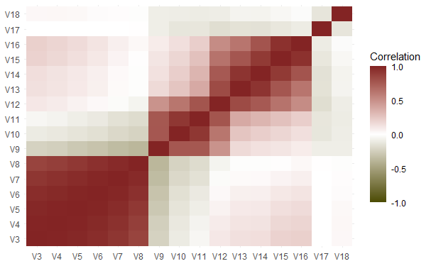

```r
#On utilise une heatmap pour mieux visualiser les corrélations
ggplot(melt_data, aes(x = x, y = y)) +
  geom_tile(aes(fill = Correlation)) +
  scale_fill_gradient2(low = muted("yellow"), mid = "white", high = muted("red"), guide = guide_colorbar(ticks = FALSE, barheight = 10), limits = c(-1,1)) +
  theme_minimal() +
  labs(x = NULL, y = NULL)
```

On retrouve nos fortes corrélations observées auparavant sur les variables 3 à 8. On peut aussi observer des fortes corrélations entre les variables 9 à 16. Il est donc important de prendre ces variables en compte lors de notre analyse.

Cependant on peut remarquer qu’il n’y a pas ou une très faible corrélation entre les variables qui constituent les résultats de la détection MA (V3-V8) et ceux des exsudats (V9-V16).

On peut visualiser la matrice de corrélation d’une autre manière, en y ajoutant un dendrogramme. Ce qui peut être intéressant pour voir les couples de variables.

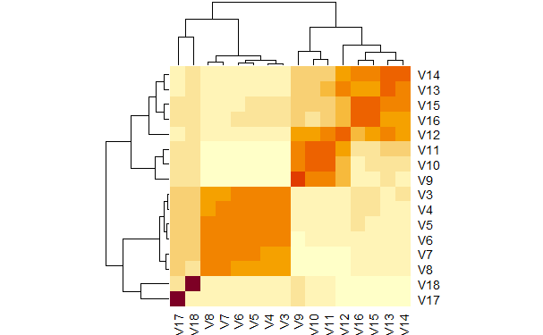

```r
#Corrélation des variables avec ajout d'un dendrogramme
heatmap(corr_data, scale = "column", margins = c(2,2))
```

On observe 3 groupes, les deux précédemments observés et un autre qui est formé des variables 17 et 18. Ce dendrogramme nous montre aussi qu’il pourrait être intéressant de regarder le nuage de points entre deux variables qui se suivent (par exemple V13 et V14), car il semblerait que dans notre cas, les premiers duo sont réalisé de cette manière par le dendrogramme.

On peut aussi s’intéresser à la distribution des variables.

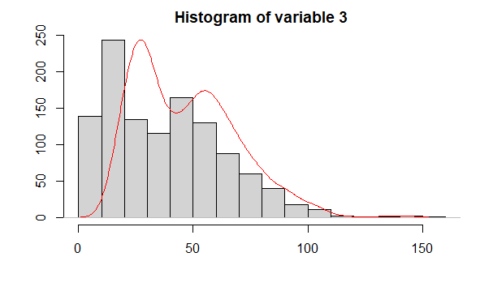

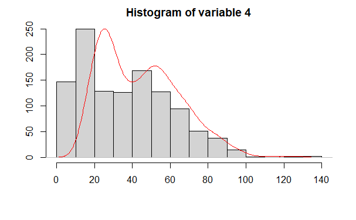

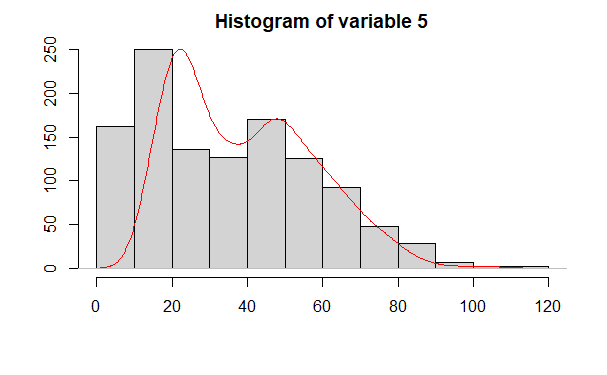

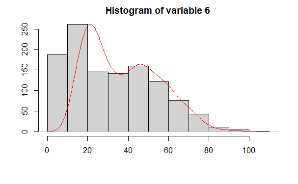

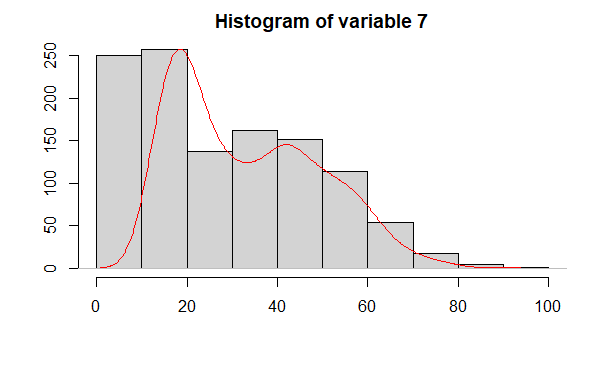

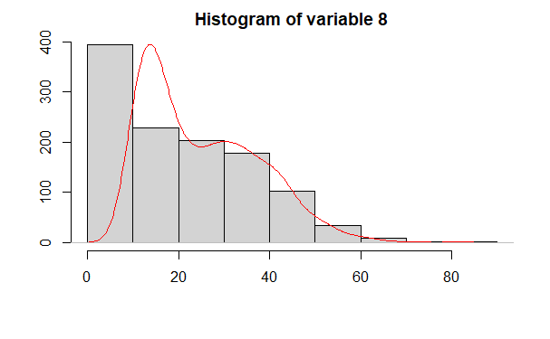

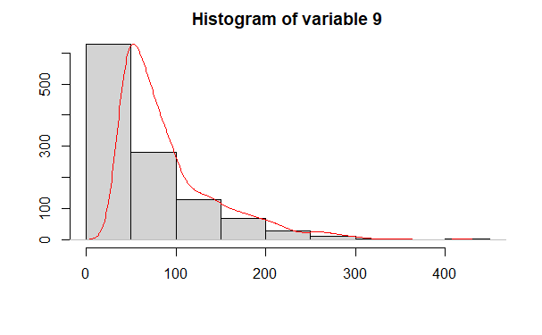

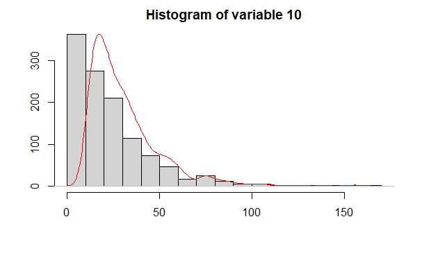

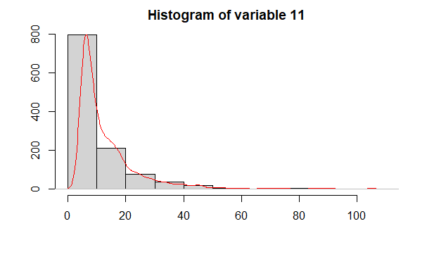

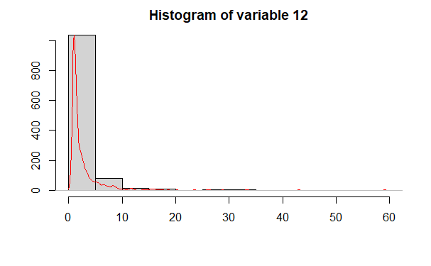

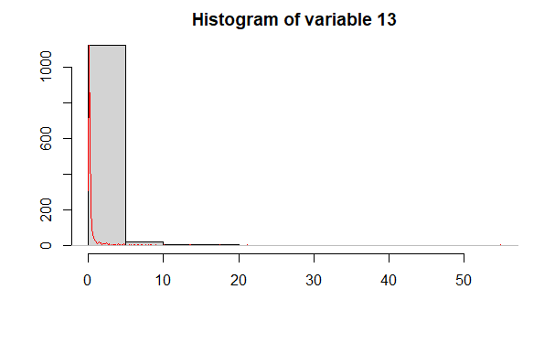

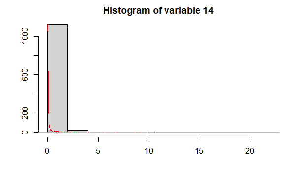

[4 more figures not shown]

```r
#Distribution des variables
for (i in 3:18){
  col <- data[,i]
  dist <- density(col)

  hist(col, xlab="",ylab="", main = paste("Histogram of variable", i))

  par(new = T) #Définit que l'on travail sur le même graphique
  plot(dist, col = "red", axes=F, xlab="", ylab="", main="")
}
```

On peut remarquer que le groupe V3-V8 suit une même distribution, qu’il en est de même pour le groupe V9-V16 et le groupe V17-V18.

On peut en conclure que nous ne sommes pas en présence de distribution normale.

On s’intéresse donc maintenant à une brève analyse des nuages de points entre les variables.

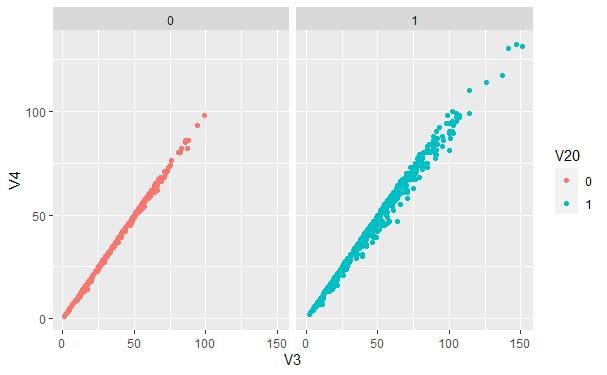

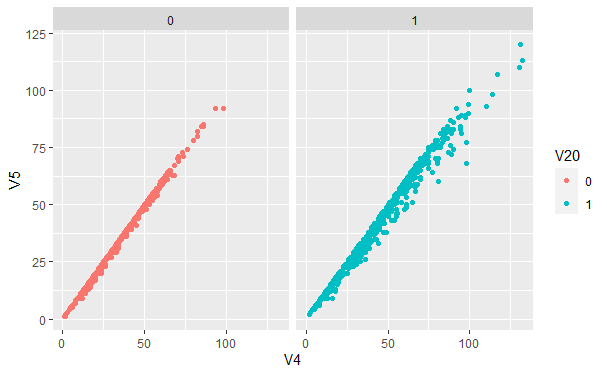

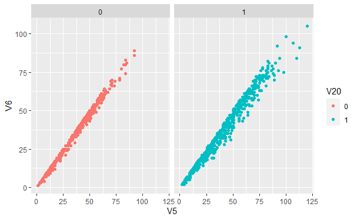

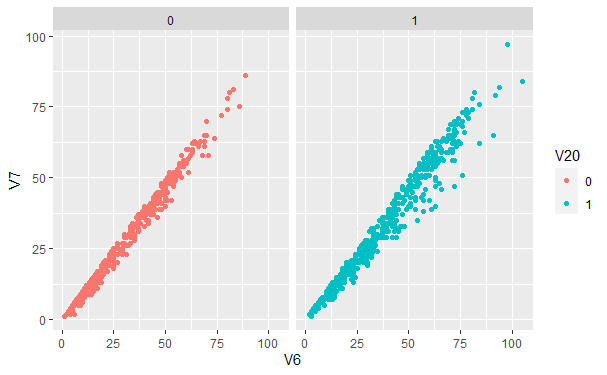

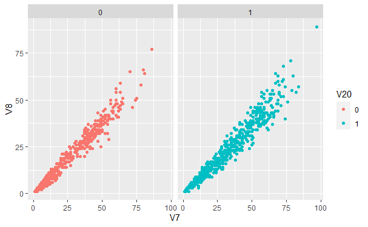

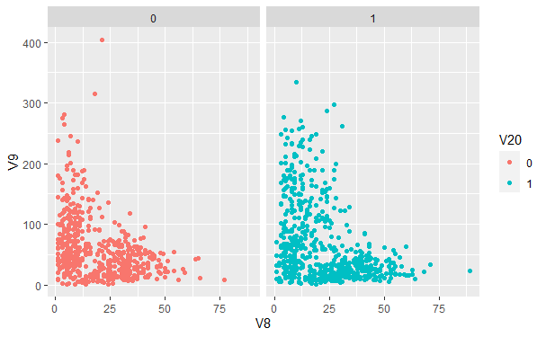

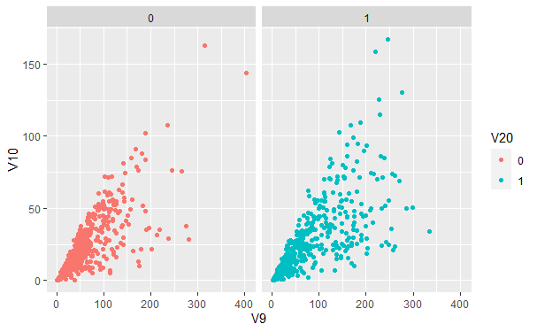

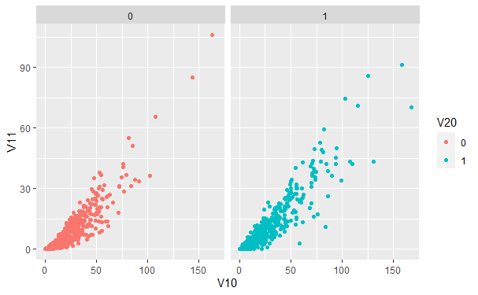

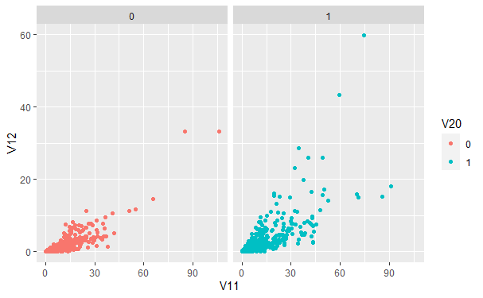

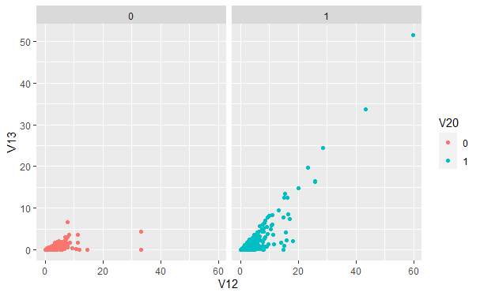

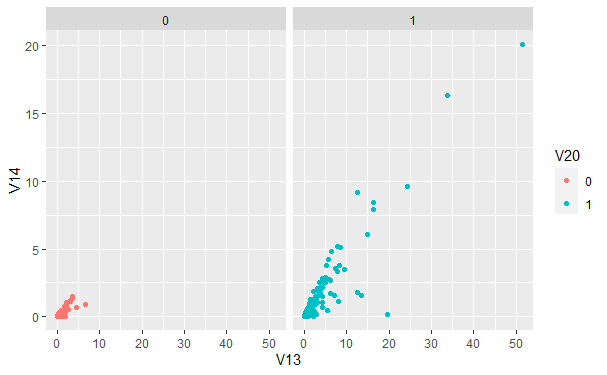

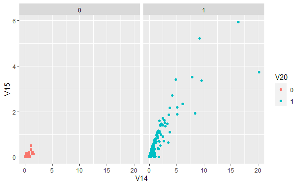

[3 more figures not shown]

```r
library(ggplot2)
#Analyse des nuages de points
for (i in 3:17){
    g <- ggplot(data, aes(x = data[,i], y = data[,i+1]))
    print(g + geom_point(aes(color = V20)) + facet_wrap(~V20)
    + xlab(paste("V",i,sep = ""))
    + ylab(paste("V",i+1,sep = "")))
}
```

Nous allons maintenant passer à l’étape suivante du projet.

# Classification non supervisée

Dans cette partie, nous allons supprimer la variable classe de notre dataset. Dans le but d’utiliser trois méthodes vu en cours : KMeans, PAM et CAH.

Pour chaque méthodes, nous déterminerons le bon nombre de profil type, en extraire les profils et les interpréter.

```r
# On commence par extraire la variable target de notre dataset
unsu_data <- data[-20]
head(unsu_data)
```

|  | V1 | V2 | V3 | V4 | V5 | V6 | V7 | V8 | V9 | V10 | V11 | V12 | V13 | V14 | V15 | V16 | V17 | V18 | V19 |
| --- | --- | --- | --- | --- | --- | --- | --- | --- | --- | --- | --- | --- | --- | --- | --- | --- | --- | --- | --- |
| 1 | 1 | 1 | 22 | 22 | 22 | 19 | 18 | 14 | 49.89576 | 17.775994 | 5.270920 | 0.771761 | 0.018632 | 0.006864 | 0.003923 | 0.003923 | 0.486903 | 0.100025 | 1 |
| 2 | 1 | 1 | 24 | 24 | 22 | 18 | 16 | 13 | 57.70994 | 23.799994 | 3.325423 | 0.234185 | 0.003903 | 0.003903 | 0.003903 | 0.003903 | 0.520908 | 0.144414 | 0 |
| 3 | 1 | 1 | 62 | 60 | 59 | 54 | 47 | 33 | 55.83144 | 27.993933 | 12.687485 | 4.852282 | 1.393889 | 0.373252 | 0.041817 | 0.007744 | 0.530904 | 0.128548 | 0 |
| 4 | 1 | 1 | 55 | 53 | 53 | 50 | 43 | 31 | 40.46723 | 18.445954 | 9.118901 | 3.079428 | 0.840261 | 0.272434 | 0.007653 | 0.001531 | 0.483284 | 0.114790 | 0 |
| 5 | 1 | 1 | 44 | 44 | 44 | 41 | 39 | 27 | 18.02625 | 8.570709 | 0.410381 | 0.000000 | 0.000000 | 0.000000 | 0.000000 | 0.000000 | 0.475935 | 0.123572 | 0 |
| 6 | 1 | 1 | 44 | 43 | 41 | 41 | 37 | 29 | 28.35640 | 6.935636 | 2.305771 | 0.323724 | 0.000000 | 0.000000 | 0.000000 | 0.000000 | 0.502831 | 0.126741 | 0 |

Maintenant que nous avons notre “unsupervised dataset”, nous pouvons appliquer les différents algorithmes cités auparavant.

Nous allons commencer par le KMeans. Mais avant d’utiliser cet algorithme, il nous faut déterminer le nombre de clusters adéquat. Cela dans le but de maximiser nos résultats. On utilise donc la méthode du coude.

Car il y a une composante aléatoire dans le clustering, nous définissons le “seed” pour générer un résultat reproductible.

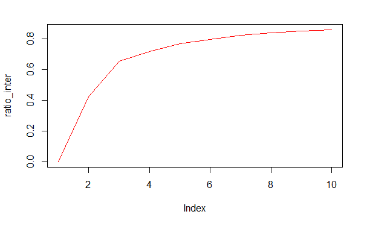

```r
#Methode du coude
#Initialise nos ratio à zéro
ratio_inter <- 0
ratio_intra <- 0
set.seed(30)

#Dans une boucle on test le KMeans pour k clusters
for (k in 1:10){
  resultat <- kmeans(unsu_data, k)
  ratio_inter[k] <- resultat$betweenss/resultat$totss
  ratio_intra[k] <- resultat$tot.withinss/resultat$totss
}

#Affichage
plot(ratio_inter, type="l", col = "red", )
```

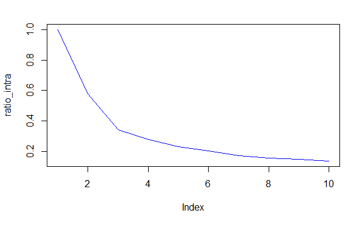

```r
plot(ratio_intra, type="l", col = "blue")
```

Il existe une autre méthode afin de déterminer le nombre de clusters pour notre algorithme KMeans. Il s’agit de la fonction “FitKMeans”, disponible dans la librairie “useful”.

Elle compare essentiellement le rapport de la somme des carrés intra-cluster pour un cluster avec k clusters, en tenant compte du nombre de lignes et de clusters. Si ce nombre est supérieur à 10, cela vaut la peine d’utiliser k+1 clusters.

```r
library(useful)
best_km <- FitKMeans(unsu_data, max.clusters = 10, seed = 30)

best_km
```

| Clusters | Hartigan | AddCluster |
| --- | --- | --- |
| 2 | 841.02974 | TRUE |
| 3 | 781.06630 | TRUE |
| 4 | 256.47383 | TRUE |
| 5 | 239.72574 | TRUE |
| 6 | 188.80042 | TRUE |
| 7 | 146.04569 | TRUE |
| 8 | 100.62268 | TRUE |
| 9 | 123.97341 | TRUE |
| 10 | 69.89303 | TRUE |

On va observer sur un graphique afin d’avoir une meilleur compréhension du résultat.

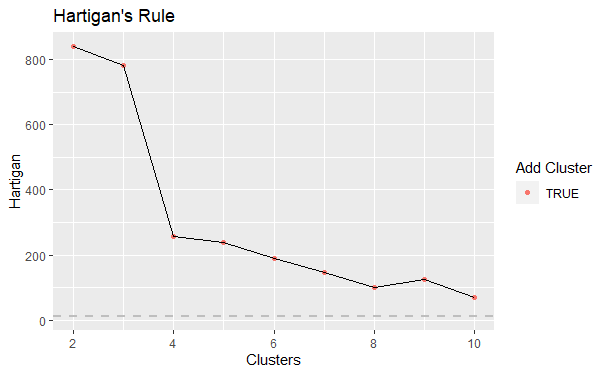

```r
PlotHartigan(best_km)
```

Ce qui nous indique ces résultats, c’est qu’il faut faudrait ajouter des clusters afin de répondre à la métrics d’Hartigan et afin d’avoir un clustering plus précis. Cependant le nombre de clusters devenant trop éléver, alors qu’initialement il n’y a que deux classes dans le dataset, nous allons rester sur nos précedents résultats. De plus, on observe ici un grand changement lors du passage à 4 clusters. Ce qui nous conforte dans l’utilisation de la méthode du coude pour notre démarche.

On utilise donc l’agorithme du KMeans avec 4 clusters.

```r
#A l'aide de la methode du coude on peut dire que le meilleur k est 4
set.seed(30)
km_data <- kmeans(unsu_data, centers = 4)
km_data
```

```
K-means clustering with 4 clusters of sizes 398, 456, 206, 91

Cluster means:
         V1        V2       V3       V4       V5       V6       V7
1 0.9899497 0.8894472 19.70352 19.09045 18.25377 16.64322 14.55528
2 1.0000000 0.9320175 62.67982 60.25439 57.99781 53.95395 49.11404
3 1.0000000 0.9320388 24.70388 23.48058 21.60680 19.21359 15.97573
4 1.0000000 0.9450549 29.86813 28.26374 25.09890 21.85714 17.67033
        V8        V9      V10       V11       V12       V13        V14
1 10.77889  37.79294 13.77515  3.518460 0.5615569 0.2063773 0.07154077
2 36.57895  34.17715 15.31933  5.043275 1.2806286 0.4845182 0.19495004
3 11.14078 116.76679 39.97488 16.297219 3.1247486 0.8166432 0.28917827
4 11.86813 209.83453 64.52036 32.546142 7.2816976 1.9132154 0.74070891
         V15        V16       V17       V18        V19
1 0.02459113 0.01052175 0.5256735 0.1089041 0.42211055
```

[output cut: 47 more lines]

Les informations ci-dessus nous donne accès aux barycentres de chaque variables, l’assignation de chaque individus à son cluster et la précision de notre clustering en regardant le ratio inter. Ce ratio inter est de 71,9%, ce qu’on peut considérer comme un résultat correct.

Car le KMeans a ses limites et il est possible que dans notre dataset, il n’y est pas de groupes distincts qui se déssinent. Afin de vérifier cela nous pouvons afficher graphiquement les résultats de notre clustering.

Cependant celui-ci peut être difficile en raison de la nature dimensionnelle élevée des données. Pour surmonter ce problème, la focntion plot effectue une mise à l’échelle multidimensionnelle pour projeter les données en deux dimensions. Elle utilise l’agorithme des PCA, et affiche sur les deux composantes principales les plus importantes.

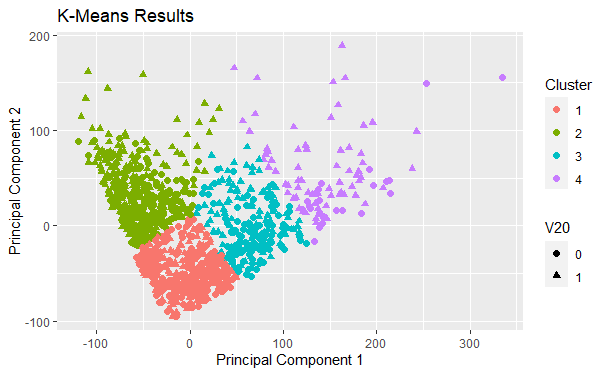

```r
#Graphique du résultat du KMeans
plot(km_data, data = data, class = "V20")
```

Ce graphique nous aide à voir qu’il semble compliqué de séparer les classes. Et que nos clusters possèdent des individus des deux classes.

Nous pouvons extraire le profil des clusters grâce à une matrice de confusion.

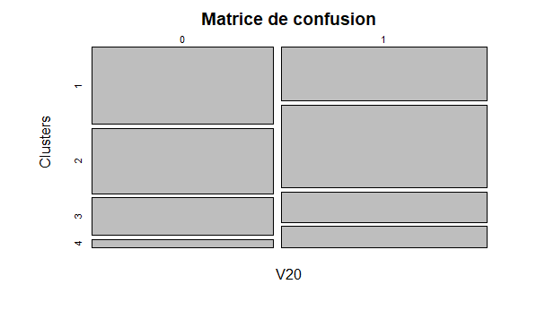

```r
#Matrice de confusion pour notre clustering
plot(table(data$V20, km_data$cluster), main="Matrice de confusion", xlab = "V20", ylab = "Clusters")
```

On remarque que nos clusters 1 et 2 possèdent plus d’individus que les clusters 3 et 4. Le clusters 4 possèdent peu d’individus négatifs. Il semblerait que ce clusters représente le mieux les individus positifs. Cependant il faut prendre en compte qu’elle reprèsente un total d’individus assez faible. Et que les clusters 1 et 2 représentes de nombreux individus positifs. Nous pouvons donc en conclure qu’il est difficile de reproduire la distinction entre individus malades et sains avec l’algorithme des KMeans.

On peut aussi réaliser un autre KMeans, avec seulement 2 clusters, puisque nous savons que notre variable cible classifie nos patients en deux catégories : malade ou sain. On analyse ensuite avec ce même graphique l’éfficacité de notre algorithme.

```r
#Test avec deux clusters pour reproduire notre variable "target"
km_data2 <- kmeans(unsu_data, centers = 2)
km_data2
```

```
K-means clustering with 2 clusters of sizes 832, 319

Cluster means:
         V1        V2       V3       V4       V5       V6       V7
1 0.9951923 0.9122596 43.58534 41.99519 40.38942 37.42548 33.83413
2 1.0000000 0.9341693 24.97806 23.64577 21.45141 18.92163 15.47962
        V8        V9      V10       V11       V12       V13       V14
1 25.19111  34.62441 14.55230  4.320277 0.9640846 0.3627768 0.1461336
2 10.61442 140.96477 45.35042 20.139611 4.1118513 1.0770510 0.3848354
         V15        V16       V17       V18       V19
1 0.06539487 0.03212265 0.5244957 0.1091665 0.2127404
2 0.13856552 0.05053320 0.5198648 0.1065138 0.6583072

Clustering vector:
   [1] 1 1 1 1 1 1 1 1 1 1 1 1 1 1 1 1 2 1 1 2 1 2 1 2 2 1 1 2 1 1 1 1 2
```

[output cut: 41 more lines]

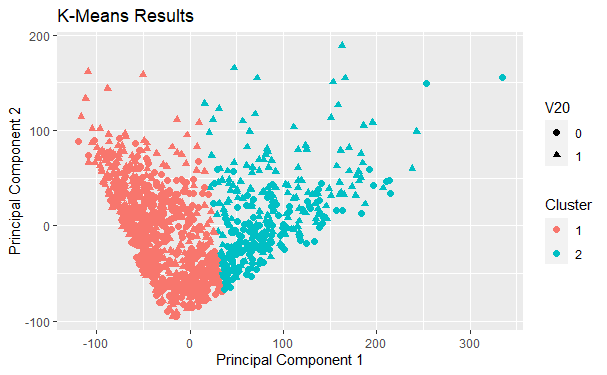

```r
plot(km_data2, data = data, class = "V20")
```

Les résultats obtenus ne sont pas bon, puisque nous avons seulement un résultat de 42,3% pour le ratio inter. De plus si on regarde le graphique obtenu, on peut voir qu’il y a une faible corrélation entre les couleurs (signification de notre clustering) et les formes (signification des classes réelles), ce qui nous indique un mauvais clustering.

Afin de vérifier cela nous utilisons une matrice de confusion.

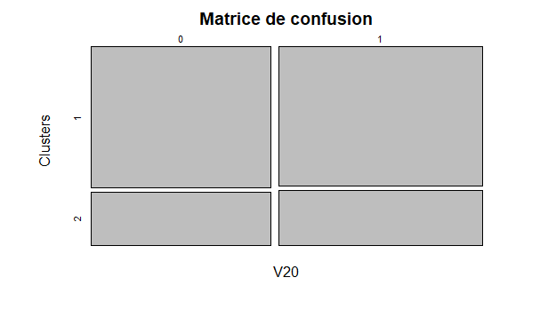

```r
plot(table(data$V20, km_data2$cluster), main="Matrice de confusion", xlab = "V20", ylab = "Clusters")
```

```r
#La classe 0 correspond à la 1 et la 1 à la 2 pour la variable V20
```

Cette matrice nous montre que notre cluster 1 correspond trop peu d’élément de la classe 0 (équivalent au cluster 1). Si les résultats étaient bon, la diagonale de la matrice aurait de fortes valeurs.

L’un des problème pour le clustering avec l’algorithme KMeans est qui est sensible au outliers (valeurs abérantes). Et lors de notre analyse descriptive, nous avons grâce aux boxplots, que notre jeu de donné possède des outliers.

Une alternative à ce problème est les K-Medoïds. Au lieu que le centre d’un cluster soit la moyenne du cluster, le centre est l’une des observations réelles du cluster. Cela s’apparente à la médiane, qui est robuste contre les valeurs aberrantes. L’algorithme le plus connu des K-Medoïds est Partitionning Around Medoids (PAM).

```r
#On importe la librairie permettant d'utiliser PAM
library(cluster)
#On passe nos data dans la matrice de distance entre les individus
X <- dist(unsu_data)
#Utilisation de l'algorithme PAM sur la matrice de distance
#On garde le même nombre de cluster que pour le kmeans
pam_data <- pam(X, k = 4)
pam_data
```

```
Medoids:
       ID
[1,] 1022 1022
[2,]  953  953
[3,] 1051 1051
[4,] 1120 1120
Clustering vector:
   [1] 1 1 2 2 3 3 3 1 1 2 2 1 2 3 2 1 2 3 2 4 3 4 3 1 4 1 2 4 3 2 1 3 4
  [34] 4 2 3 1 2 3 1 2 1 4 1 1 3 2 1 4 1 1 3 1 1 3 2 1 4 3 4 1 4 1 4 2 1
  [67] 2 2 4 2 2 1 2 2 2 3 3 1 1 1 2 1 2 4 3 3 4 3 1 1 1 2 2 1 4 4 2 4 3
 [100] 4 3 3 4 1 4 3 4 1 1 3 3 3 2 4 2 1 3 3 4 2 1 1 3 3 1 1 3 2 2 2 3 1
 [133] 2 2 3 1 3 2 1 1 2 1 4 3 4 2 1 2 3 4 3 1 2 1 1 3 4 3 3 2 3 3 4 1 2
 [166] 1 1 2 1 1 1 3 3 1 1 1 2 1 2 2 3 1 4 3 2 4 2 3 2 3 2 4 3 3 2 1 2 3
 [199] 4 1 1 3 4 4 1 2 1 1 2 3 1 2 4 4 1 4 2 4 2 3 2 1 1 4 2 4 1 2 1 2 1
 [232] 1 4 3 2 1 1 1 1 4 3 4 2 1 1 4 1 1 2 3 3 2 3 1 3 4 2 1 1 4 1 3 3 1
```

[output cut: 31 more lines]

On obtient le résultat ci-dessus, nous nous intéressons au résultat du build et du swap de la fonction objective. On remarque, que nos résultats ne s’améliorent que très peu après la deuxième étape de l’algorithme (le swap).

On va maintenant observer la silhoutte de notre clustering, ce qui nous donnera plus d’information sur l’éfficacité de notre algorithme.

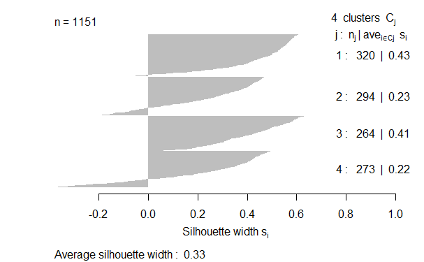

```r
#Afin d'afficher graphiquement le résultat, on utilise la fonction silhoutte
sil <- silhouette(pam_data)
#On met le paramètre border à NA afin d'éviter des problèmes d'affichage du graphique
plot(sil, main = "", border = NA)
```

Nous savons que plus l’average width est élevée, plus notre clustering est bon. Or dans notre cas, elle est de 0.33. Un consensus scientifique autour de la valeur silhouette nous dit qu’une valeur de 0.33 correspond à une structure faible, presque une structure artificielle.

Il nous faut donc utiliser une autre méthode. Il est possible que nos classes ne soient pas linéairement séparable.

On utilise donc une dernière méthode de clustering. La classification hiérachique ascendante (CAH). Cette méthode construit des clusters dans des clusters. Elle ne requière pas d’un nombre initial de clusters. Cette méthode peut être vue comme un arbre, représenté graphiquement par un dendrogramme.

```r
#On utilise la fonction hclust pour utiliser l'algorithme de la CAH
hc_data <- hclust(X, method = "ward.D")
plot(hc_data, labels = FALSE)
#Séparation en 4 clusters
rect.hclust(hc_data, k = 4, border = "red")
```

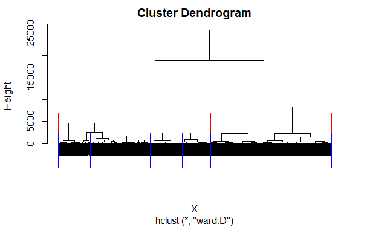

```r
#Séparation en 8 clusters
rect.hclust(hc_data, k = 8, border = "blue")
```

On observe que avec 4 clusters, chacun d’entre eux possèdent un poids élevé. Afin de réalisé un test nous avons aussi regardé avec 8 clusters. Le poids semble être divisé par deux, mais pour cela nous avons du doubler le nombre de clusters. Cela n’est pas donc pas intéressant dans notre cas. Nos 4 clusters on un poids très élevé, ce qui ne permet pas de dire que nous avons un bon clustering. Peut importe la méthode nos résultats sont mauvais.

On en déduit que la classification non supervisé ne marche pas. Cela peut s’expliquer par le fait que certaines variables n’ont pas de rapport avec le phénomène observé (ici la variable V20). Ces variables biaisent donc nos résultats.

Cependant, cela ne sera pas le cas avec un arbre de décision, qui lui regarde variable par variable. Ce qui nous amène au point suivant.

# Classification supervisée

Dans cette partie nous allons procéder à l’apprentissage d’un arbre de classification pour la prédiction de la variable classe en fonction des variables restantes.

Nous allons utiliser un protocole d’apprentissage par Booststrap, indiquer les performances de l’arbre appris, visualiser et interpréter l’arbre induit en analysant les principales règles de décision.

On relie nos données.

```r
#On récupère nos données depuis le fichier texte
data = read.table("messidor_features.txt", header = FALSE, sep = ",")
#On définit la varibale 20 comme une variable catégorielle
data$V20 = as.factor(data$V20)
head(data)
```

|  | V1 | V2 | V3 | V4 | V5 | V6 | V7 | V8 | V9 | V10 | V11 | V12 | V13 | V14 | V15 | V16 | V17 | V18 | V19 | V20 |
| --- | --- | --- | --- | --- | --- | --- | --- | --- | --- | --- | --- | --- | --- | --- | --- | --- | --- | --- | --- | --- |
| 1 | 1 | 1 | 22 | 22 | 22 | 19 | 18 | 14 | 49.89576 | 17.775994 | 5.270920 | 0.771761 | 0.018632 | 0.006864 | 0.003923 | 0.003923 | 0.486903 | 0.100025 | 1 | 0 |
| 2 | 1 | 1 | 24 | 24 | 22 | 18 | 16 | 13 | 57.70994 | 23.799994 | 3.325423 | 0.234185 | 0.003903 | 0.003903 | 0.003903 | 0.003903 | 0.520908 | 0.144414 | 0 | 0 |
| 3 | 1 | 1 | 62 | 60 | 59 | 54 | 47 | 33 | 55.83144 | 27.993933 | 12.687485 | 4.852282 | 1.393889 | 0.373252 | 0.041817 | 0.007744 | 0.530904 | 0.128548 | 0 | 1 |
| 4 | 1 | 1 | 55 | 53 | 53 | 50 | 43 | 31 | 40.46723 | 18.445954 | 9.118901 | 3.079428 | 0.840261 | 0.272434 | 0.007653 | 0.001531 | 0.483284 | 0.114790 | 0 | 0 |
| 5 | 1 | 1 | 44 | 44 | 44 | 41 | 39 | 27 | 18.02625 | 8.570709 | 0.410381 | 0.000000 | 0.000000 | 0.000000 | 0.000000 | 0.000000 | 0.475935 | 0.123572 | 0 | 1 |
| 6 | 1 | 1 | 44 | 43 | 41 | 41 | 37 | 29 | 28.35640 | 6.935636 | 2.305771 | 0.323724 | 0.000000 | 0.000000 | 0.000000 | 0.000000 | 0.502831 | 0.126741 | 0 | 1 |

Maintenant que nous avons récupéré nos données, nous pouvons réaliser notre apprentissage.

Pour réaliser un apprentissage supervisé, nous allons séparer notre dataset en un trainset et un testset, dans le but de vérifier les résultats de notre algorithme.

```r
#Taille du train
smp_size <- floor(0.8 * nrow(data))

#On donne seed pour obtenir tout le temps la même partition
set.seed(12)
train_ind <- sample(seq_len(nrow(data)), size = smp_size)

#Split en trainset et testset
trainset <- data[train_ind, ]
testset <- data[-train_ind, ]
```

Maintenant que nous avons notre testset et trainset, nous allons préparer nos dataframes pour les utiliser dans un algortihme d’arbre de décision et xgboost.

Nous allons commencer par un algorithm de decision tree.

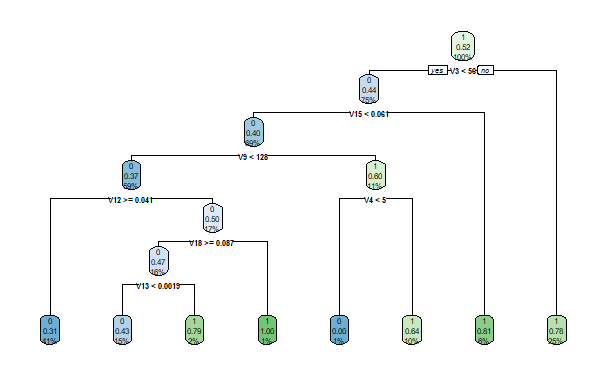

```r
#Import des librairies utiles pour faire un arbre
library(rpart)
library(rpart.plot)
#Définition de l'arbre et affichage de celui-ci
fit <- rpart(trainset$V20~., data = trainset)
rpart.plot(fit)
```

Grâce à cette arbre nous pouvons visualiser les principales règles. On peut voir sur chaque feuilles la classe majoritaire de la feuille (0 ou 1), ainsi que le pourcentage d’individus total de la feuille. On remarque que nous avons 7 règles de décisions, et que nous avons donc 8 feuilles à notre arbre. Dont 5 correspondants à la classe 1 (individus malade) et 3 correspondants à la classe 0 (individus sain).

Une autre visualisation est possible, moins complète, mais qui met plus en valeur les régles de l’arbre et les classes obtenues suite a ces régles.

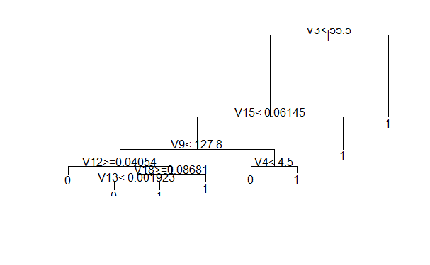

```r
#On peut réaliser une autre méthode d'affichage
plot(fit)
text(fit)
```

De plus les règles sont données avec une plus grande précision après la virgule. On peut maintenant afficher notre arbre sans utiliser de graphique, afin d’avoir plus d’information sur les règles obtenus.

```r
#Ici on affiche les règles de notre arbre, la classe majoritaire de chaque régles
fit
```

```
n= 920

node), split, n, loss, yval, (yprob)
      * denotes terminal node

 1) root 920 442 1 (0.4804348 0.5195652)
   2) V3< 55.5 694 302 0 (0.5648415 0.4351585)
     4) V15< 0.061455 637 256 0 (0.5981162 0.4018838)
       8) V9< 127.8097 540 198 0 (0.6333333 0.3666667)
        16) V12>=0.0405425 381 119 0 (0.6876640 0.3123360) *
        17) V12< 0.0405425 159  79 0 (0.5031447 0.4968553)
          34) V18>=0.0868095 150  70 0 (0.5333333 0.4666667)
            68) V13< 0.0019225 136  59 0 (0.5661765 0.4338235) *
            69) V13>=0.0019225 14   3 1 (0.2142857 0.7857143) *
          35) V18< 0.0868095 9   0 1 (0.0000000 1.0000000) *
       9) V9>=127.8097 97  39 1 (0.4020619 0.5979381)
        18) V4< 4.5 7   0 0 (1.0000000 0.0000000) *
        19) V4>=4.5 90  32 1 (0.3555556 0.6444444) *
     5) V15>=0.061455 57  11 1 (0.1929825 0.8070175) *
   3) V3>=55.5 226  50 1 (0.2212389 0.7787611) *
```

On remaque les feuilles obtenus sur les 920 individus utilisés pour notre apprentissage, certaines ont très bien classées les individus, et la classe majortiaire de la feuille est supérieur à 70%. Alors que certaines feuilles ont moins bien classés les individus.

Cette affichage nous montre : la règle, le nombre d’individus de la classe majoritaire, puis le nombre d’individus de la classe minoritaire. Enfin nous avons la probabilité d’appartenance à une classe. Par exemple pour la règle 3 qui nous dit que la variable V3 doit être supérieur à 55.5, nous avons une probabilité de 78% d’être dans la classe 1.

On peut maintenant s’intéresser à la performance de notre arbre. Pour cela nous utilisons une matrice de confusion.

```r
#Pour calculer la performance de notre arbre nous allons utiliser une matrice de confusion
ypred <- predict(fit, testset, type = "class")
result <- confusionMatrix(ypred, testset$V20)
result
```

```
Confusion Matrix and Statistics

          Reference
Prediction  0  1
         0 71 53
         1 27 80

               Accuracy : 0.6537
                 95% CI : (0.5885, 0.7149)
    No Information Rate : 0.5758
    P-Value [Acc > NIR] : 0.009414

                  Kappa : 0.315

 Mcnemar's Test P-Value : 0.005189

            Sensitivity : 0.7245
            Specificity : 0.6015
         Pos Pred Value : 0.5726
         Neg Pred Value : 0.7477
             Prevalence : 0.4242
         Detection Rate : 0.3074
   Detection Prevalence : 0.5368
      Balanced Accuracy : 0.6630

       'Positive' Class : 0
```

On observe que nous avons une précision de 65%, ce qui n’est pas très élevé. On peut donc utiliser une méthode par boostrap afin d’améliorer nos résulats.

```r
#On définie nos vecteurs de variables train et test et nos vecteurs de variable target train et test
#On convertie nos dataframe en matrice car xgboost ne prend en entrée que des matrices
X_data <- as.matrix(data[-20])
Y_data <- as.matrix(data[20])
```

Maintenant que nous avons nos matrices, contenant nos variables dans un première matrice et notre variables target dans une seconde. Nous pouvons utiliser l’algorithme xgboost afin de réaliser un arbre de décision par boostrap.

On règle les paramètres suivants : eta contrôle le taux d’apprentissage, il échelonne la contribution de chaque arbre. Utilisé pour éviter l’overfitting en rendant le processus de boosting plus conservateur. Une valeur plus faible pour eta implique une valeur plus grande pour nrounds. Une valeur eta faible signifie un modèle plus robuste au surajustement mais plus lent à calculer. nrounds nous permet de fixer le nombre d’itération que l’agorithme fait. Enfin max.depth nous permet de contrôler la profondeur maximale de l’arbre.

En jouant sur ces hyperparamètre, nous pouvons améliorer les performances de notre algorithme.

```r
#XGBOOST
library(xgboost)
boostedtree <- xgboost(data = X_data, label = Y_data, eta = .3, nrounds = 20, max.depth = 8)
```

On peut donc maintenant regarder les variables les plus importantes lors de l’apprentissage de notre arbre. Afin de comprendre quelles variables sont les plus utiles dans l’apprentissage de l’arbre.

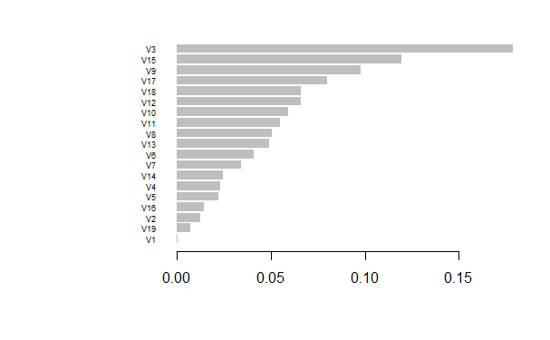

```r
#install.packages("DiagrammeR")
library(DiagrammeR)
xgb.plot.importance(xgb.importance(boostedtree, feature_names = colnames(X_train)))
```

On voit que la variable 3 est la plus importante. La variable 15 et 9 le sont aussi.

# Conclusion